# Motor Trend: Fuel Economy Study

Zach Olivier

2/23/2018

### Executive Summary: Fuel Economy Study

Miles-per-Gallon (MPG) is possibly the most impactful metric used to judge new vehicles in the automotive industry. MPG is often the deciding factor in a new car purchase - higher MPG is saved money every time you fill up - driving down cost of ownership. MPG conscious consumer behavior forces automakers to produce efficient “fuel-sipping” cars. MPG is a true competitive advantage in the race for sales.

Further, the Environmental Protection Agency (EPA) has imposed strict MPG threshold goals for all OEMs. Setting fleet-wide average MPG goals at 30+ MPG by 2022 - automakers are investing heavily in engineering to improve fuel economy of their vehicles.

Complacency in fuel economy innovation is a death sentence in today’s auto market. Customers will buy the competitor’s vehicle that provides a lower lifetime cost. The EPA will fiscally punish car brands not meeting their strict MPG goals - possibly putting major players out of business. MPG is extremely important in the automotive landscape - and may even determine the fate of the business entirely.

Today we take MPG under the microscope to examine which features of a car improve or degrade fuel economy performance. We will rigorously analyze the relationship between transmission type and MPG performance.

[output not shown]

### Explore: Which transmission drives MPG performance?

Surprisingly, manual transmissions tower over automatic transmission in fuel economy performance. Only two of the manual transmission vehicles sampled fell below the industry median miles per gallon.

```
    The mean MPG of manual transmission vehicles is 24 mpg versus just 17 for automatic.
```

Intuitively - we would expect automatic transmissions to be more fuel-efficient. Drivers manually shifting gears is imperfect and these slight delays in gear shift cause more fuel consumption. Our initial findings seem to show the exact opposite.

Is the final answer? Should you buy a manual transmission to save the most money? Should OEMs stop making automatic vehicles all together?

Not quite. Let’s continue to dig deeper.

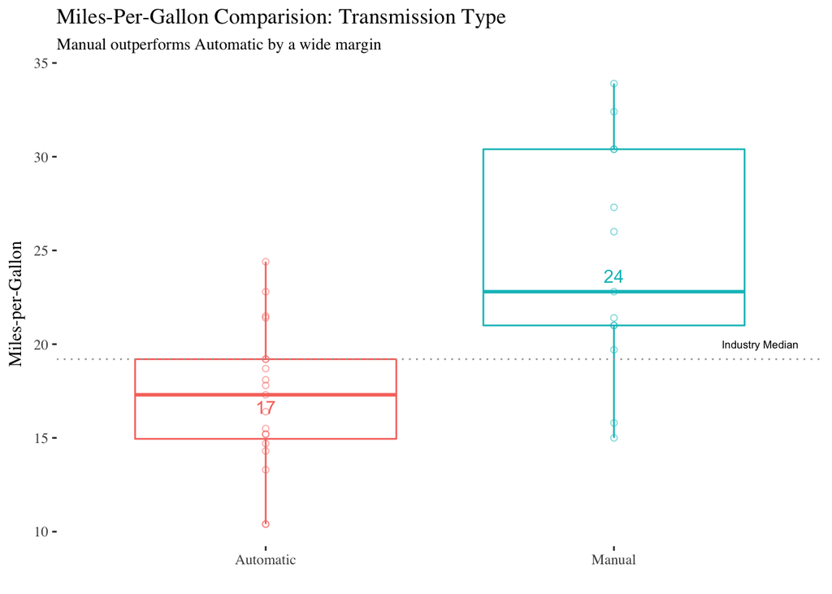

### Explore: Modeling the affect of tranmission

There has to be more to the relationship between MPG and transmission. Are there other variables could help explain the difference in MPG between transmission type?

To examine this we first build a simple one variable linear regression. We regress transmission on mpg and interpret the results.

```
    We see strong evidence that the effect of manual transmission is not zero (coefficient p = .000285 < .05).

    The F-statistic tells us there is some overall relationship between transmission and mpg.

    The multiple R^2 however is not strong, only ~36% of the total variance is explained by this simple model.
```

This leads us to believe that although there is some relationship between manual transmission and mpg, we do not have the full picture.

```
##
## Call:
## lm(formula = mpg ~ am, data = mtcars)
##
## Residuals:
##     Min      1Q  Median      3Q     Max
## -9.3923 -3.0923 -0.2974  3.2439  9.5077
##
## Coefficients:
##             Estimate Std. Error t value Pr(>|t|)
## (Intercept)   17.147      1.125  15.247 1.13e-15 ***
## amManual       7.245      1.764   4.106 0.000285 ***
## ---
## Signif. codes:  0 '***' 0.001 '**' 0.01 '*' 0.05 '.' 0.1 ' ' 1
##
## Residual standard error: 4.902 on 30 degrees of freedom
## Multiple R-squared:  0.3598, Adjusted R-squared:  0.3385
## F-statistic: 16.86 on 1 and 30 DF,  p-value: 0.000285
```

### Explore: What variables “explain” fuel economy?

To find other variable that may better explain the relationship between MPG and Transmission we need to investigate which variables are correlated with MPG and Transmission.

Looking down the left hand column of the pairs plot below we notice some interesting behaviors of our sample.

```
    Manual tranmissions in our sample have relatively low displacement values.

    Manual transmissions in our sample have relatively low horsepower values.

    Manual transmission in our sample have relatively low weight values.
```

Each of these variables have high correlation with MPG - which may be biasing our results. Perhaps weight, horsepower, and displacement are the “true” indicators of mpg performance, and transmission in our simple model is getting attributed these affects.

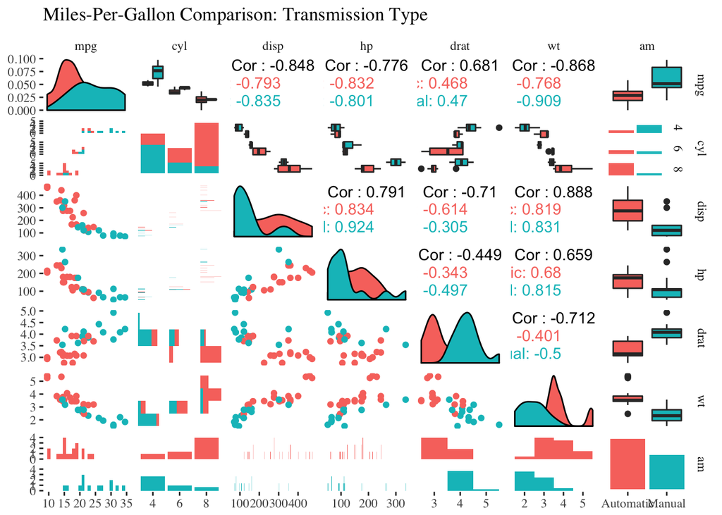

### Explore: Modeling the affect of multiple variables

To test our hypothesis that transmission is getting assigned the affect of other variables in our simple model - we will fit a multiple models and compare them against each other.

First we see the affect of adding displacement, weight and horsepower to the simple model.

```
    Adding weight, horsepower and displacement gives us a significant gain in variance explaination (F-statistic)
```

Next we compare a model with all variables correlated with mpg expect transmission to a model with all variables including transmission. This will tell us if adding transmission to a model with all other variables adds significant variance explanation.

```
    Adding transmission to the model does not give us a significant gain in variance explaination. (F-statistic)
```

```
## Analysis of Variance Table
##
## Model 1: mpg ~ am
## Model 2: mpg ~ disp + wt + hp + am
##   Res.Df    RSS Df Sum of Sq      F    Pr(>F)
## 1     30 720.90
## 2     27 179.91  3    540.99 27.063 2.715e-08 ***
## ---
## Signif. codes:  0 '***' 0.001 '**' 0.01 '*' 0.05 '.' 0.1 ' ' 1
```

```
## Analysis of Variance Table
##
## Model 1: mpg ~ disp + wt + hp
## Model 2: mpg ~ disp + wt + hp + am
##   Res.Df    RSS Df Sum of Sq      F Pr(>F)
## 1     28 194.99
## 2     27 179.91  1    15.083 2.2636 0.1441
```

### Conclusion: Transmission Does Not Explain MPG

By including weight, horsepower and displacement in our model we see that transmission no longer gives us enough explanation of variance to keep in the model.

[output not shown]

Didn’t my simple model show there was some affect of transmission on mpg? Yes.

However, the relationship did not explain enough variance after the other highly correlated variables were included in the model. The F statistic from our anova results is based on the number of predictors added to the model - the added variable needs to overcome a certain threshold of variance explained to be included over the penalty of adding another predictor. In our case, transmission did not overcome this threshold.

```
    Each unit increase in weight reduces mpg performance by ~4 mpg holding displacement and horsepower constant.
```

```
##                  Estimate Std. Error     t value     Pr(>|t|)
## (Intercept) 37.1055052690 2.11081525 17.57875558 1.161936e-16
## disp        -0.0009370091 0.01034974 -0.09053451 9.285070e-01
## wt          -3.8008905826 1.06619064 -3.56492586 1.330991e-03
## hp          -0.0311565508 0.01143579 -2.72447633 1.097103e-02
```

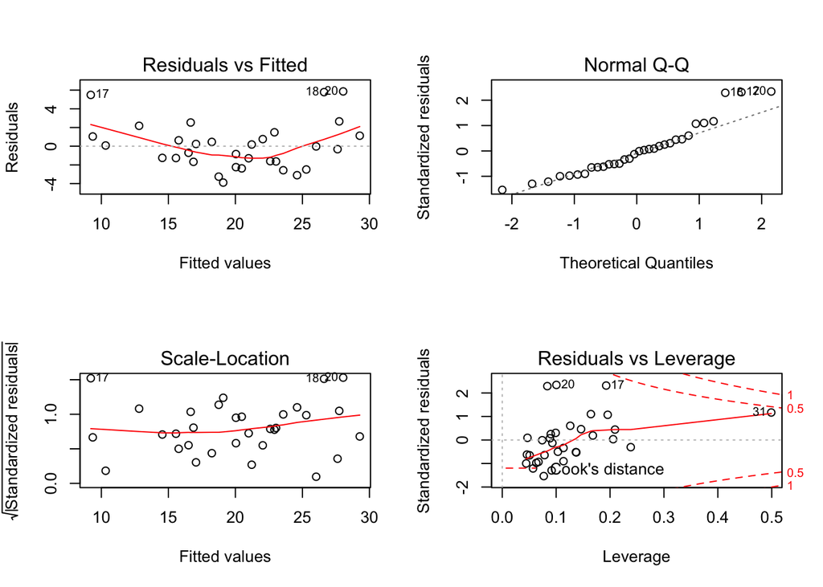